# MScA, Linear and Non-Linear Models (31010) Week 2 Workshop Non-Linear Optimization and Maximum Likelihood Estimation

© Yuri Balasanov, iLykei

**This project helps understanding non-linear optimization techniques and their aplication to maximum likelihood estimation**.

# 1 Non-Linear Optimization, MLE for Normal Distribution

Create function returning negative log-likelihood of normal distribution with parameters $<\theta_1,\theta_2>^T=<\mu,\sigma^2>^T$

$$LL(\theta_1,\theta_2;y)=\frac{n}{2}\log(2\pi\sigma^2)+\frac{1}{2\sigma^2}\sum_{i=1}^{n}(y_i-\mu)^2 .$$

The function returns a scalar value: the value of the LL() function.  
The first argument is the vector of parameters’ values $<\mu,\sigma^2>$, the second argument is the sample.

For example, the function declaration can be `Negative.LL.Normal<-function(mu.Sig.parameters,Sample.Vector)`, where `mu.Sig.parameters` is the vector $<\mu,\sigma^2>$ and `Sample.Vector` is the given sample from the file `sample_for_optimization.csv`.  
The code of the function is not shown.  
Write it yourself.

(Skipped Code)

Read the data.

```r
Norm.Sample.Vector<-read.csv(file=paste(dataPath,"sample_for_optimization.csv",sep="/"),header=TRUE,sep=",")[,1]
head(Norm.Sample.Vector)
```

```
## [1] 12.6567272 10.8362391  4.1087307 10.9831141 10.7719944 -0.9756093
```

```r
var(Norm.Sample.Vector)
```

```
## [1] 24.75509
```

Optimize the negative log-likelihood function using `optim()`

```r
Optimized.Negative.Log.Likelihood.optim<-optim(c(7,4),
                                               Negative.LL.Normal,
                                               Sample.Vector=Norm.Sample.Vector,
                                               method="L-BFGS-B",
                                               hessian=TRUE,
                                               lower=c(-Inf,0),
                                               control=list(trace=1))
names(Optimized.Negative.Log.Likelihood.optim)
```

```
## [1] "par"         "value"       "counts"      "convergence" "message"
## [6] "hessian"
```

Observe the variables in object `Optimized.Negative.Log.Likelihood.optim`

```r
Optimized.Negative.Log.Likelihood.optim$par
```

```
## [1] 10.22552 24.73032
```

```r
Optimized.Negative.Log.Likelihood.optim$value
```

```
## [1] 3022.954
```

```r
Optimized.Negative.Log.Likelihood.optim$counts
```

```
## function gradient
##       17       17
```

```r
Optimized.Negative.Log.Likelihood.optim$convergence
```

```
## [1] 0
```

**convergence**  
*An integer code. 0 indicates successful completion (which is always the case for “SANN” and “Brent”). Possible error codes are*

*1 indicates that the iteration limit maxit had been reached.*  
*10 indicates degeneracy of the Nelder–Mead simplex.*  
*51 indicates a warning from the “L-BFGS-B” method; see component message for further details.*  
*52 indicates an error from the “L-BFGS-B” method; see component message for further details.*

```r
Optimized.Negative.Log.Likelihood.optim$message
```

```
## [1] "CONVERGENCE: REL_REDUCTION_OF_F <= FACTR*EPSMCH"
```

```r
Optimized.Negative.Log.Likelihood.optim$hessian
```

```
##               [,1]          [,2]
## [1,]  4.043619e+01 -2.273737e-07
## [2,] -2.273737e-07  8.175431e-01
```

Make a filled contour plot of the negative log-likelihood function.

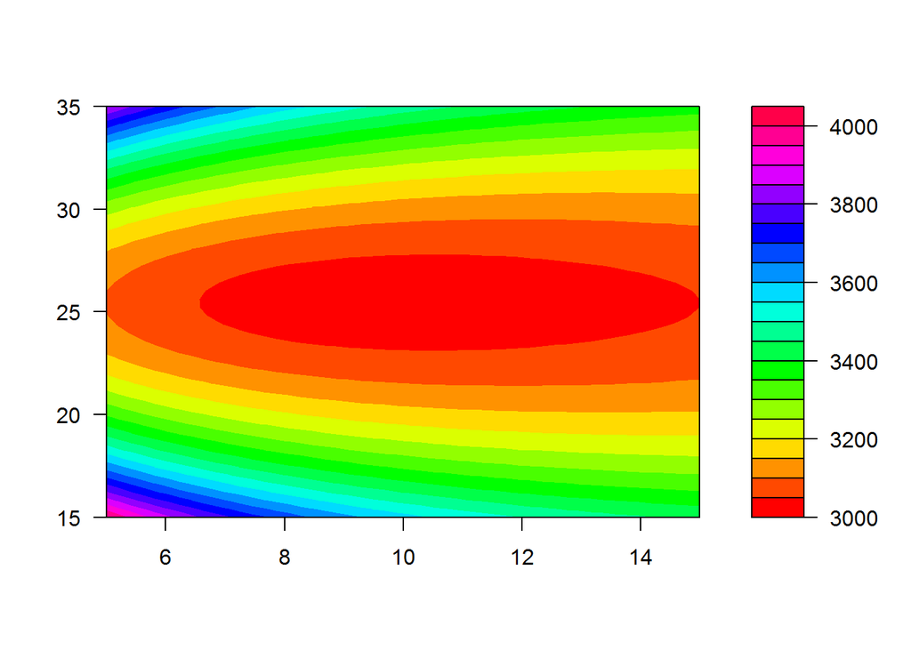

```r
#Plot the objective function
Data.To.Plot.x<-seq(from=5,to=15,length.out=50)
Data.To.Plot.y<-seq(from=15,to=35,length.out=50)


Term.1<-length(Norm.Sample.Vector)/2*outer(log(2*pi*Data.To.Plot.y),rep(1,length(Data.To.Plot.y)))
Term.2<-outer(rep(1,length(Data.To.Plot.x)),unlist(lapply(Data.To.Plot.x,FUN=function(vector.element,Data.Vector) sum((Data.Vector-vector.element)^2),Norm.Sample.Vector)))*outer(1/2/Data.To.Plot.y,rep(1,length(Data.To.Plot.y)))

Negative.Log.Likelihood.Data<-Term.1+Term.2
filled.contour(Data.To.Plot.x,Data.To.Plot.y,Negative.Log.Likelihood.Data,color.palette=rainbow,nlevels=20)
```

## 1.1 Example of Using `filled.contour`

In order to understand how to prepare the data for `filled.contour` consider the following example.

Make the sample of all zeros:

```r
(Test.Norm.Sample.Vector<-rep(0,10))
```

```
##  [1] 0 0 0 0 0 0 0 0 0 0
```

Create vectors of points on X-axis and y-axis:

```r
(Test.Data.To.Plot.y<-c(10,20,25))
```

```
## [1] 10 20 25
```

```r
(Test.Data.To.Plot.x<-c(1,2,3))
```

```
## [1] 1 2 3
```

Create 3x3 matrix of points on Y-Axis

```r
outer(Test.Data.To.Plot.y,rep(1,3))
```

```
##      [,1] [,2] [,3]
## [1,]   10   10   10
## [2,]   20   20   20
## [3,]   25   25   25
```

And another matrix of points on X-axis

```r
outer(rep(1,3),Test.Data.To.Plot.x)
```

```
##      [,1] [,2] [,3]
## [1,]    1    2    3
## [2,]    1    2    3
## [3,]    1    2    3
```

Then create the matrix `Contour.Plot.Data` of $x_i+y_j$ for all values of i, j.

```r
(Contour.Plot.Data<-outer(Test.Data.To.Plot.y,rep(1,3))+outer(rep(1,3),Test.Data.To.Plot.x))
```

```
##      [,1] [,2] [,3]
## [1,]   11   12   13
## [2,]   21   22   23
## [3,]   26   27   28
```

Use `filled.contour()` to create the plot:

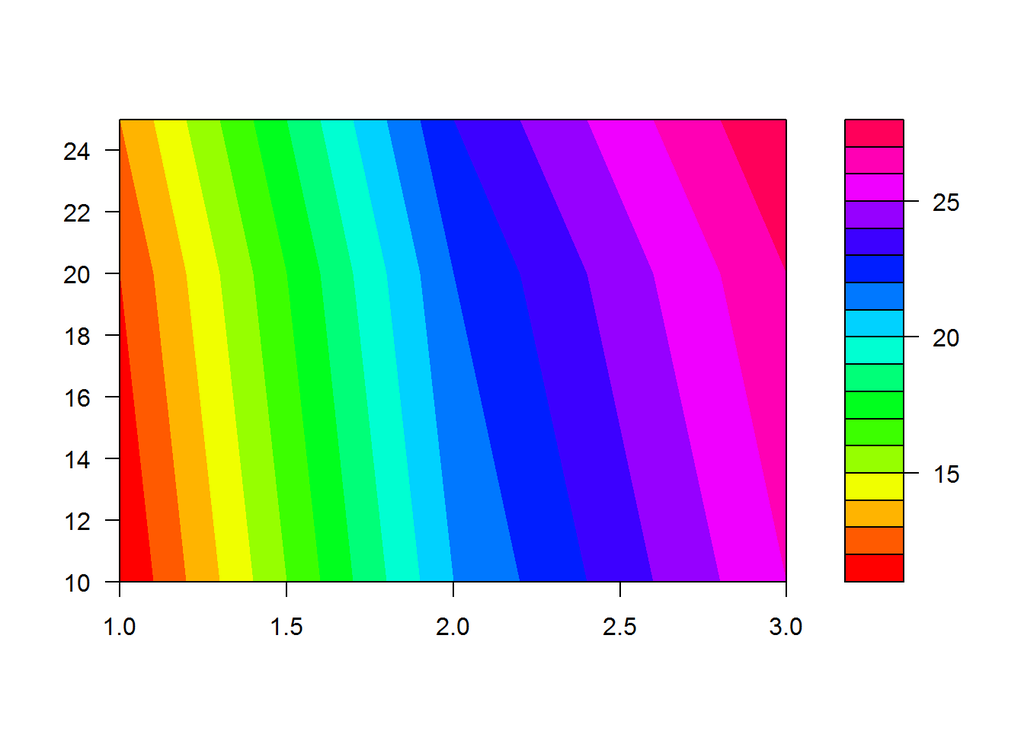

```r
filled.contour(Test.Data.To.Plot.x,Test.Data.To.Plot.y,Contour.Plot.Data,color.palette=rainbow)
```

**End of Example**

## 1.2 Analysis of the obtained estimates

Compare `Optimized.Negative.Log.Likelihood.optim$par` with `c(mean(Norm.Sample.Vector),var(Norm.Sample.Vector))`

```r
rbind(Mean.Var=c(mean(Norm.Sample.Vector),var(Norm.Sample.Vector)),
      Optim.Output=Optimized.Negative.Log.Likelihood.optim$par)
```

```
##                  [,1]     [,2]
## Mean.Var     10.22552 24.75509
## Optim.Output 10.22552 24.73032
```

Why `var(Norm.Sample.Vector))` is different from `Optimized.Negative.Log.Likelihood.optim$par[2]`?

**Code formula transforming `Optimized.Negative.Log.Likelihood.optim$par[2]` into a value of `var(Norm.Sample.Vector))`**

(Skipped Code)

```
##                              [,1]     [,2]
## Mean.Var                 10.22552 24.75509
## Optim.Output.Transformed 10.22552 24.75508
```

# 2 Fisher’s Score, Fisher’s Information

Create `Biased.Var` of the sample `Norm.Sample.Vector` as

```r
(Biased.Var<- var(Norm.Sample.Vector)*(length(Norm.Sample.Vector)-1)/length(Norm.Sample.Vector))
```

```
## [1] 24.73033
```

## 2.1 Fisher’s Score

Fisher’s score calculated at MLE is expected to be equal to zero.

Calculate $\frac{dLL(\mu,\sigma^2)}{d\mu}=\frac{1}{\sigma^2} \sum_{i=1}^{n}(y_i-\mu)$

(Skipped Code)

```
## [1] -2.585847e-14
```

and $\frac{dLL(\mu,\sigma^2)}{d\sigma^2}=-\frac{n}{2\sigma^2}+\frac{1}{2\sigma^4} \sum_{i=1}^{n}(y_i-\mu)^2$

(Skipped Code)

```
## [1] 3.552714e-15
```

## 2.2 Observed Fisher’s Information

Recall the Hessian of the negative log-likelihood function:

```r
Optimized.Negative.Log.Likelihood.optim$hessian
```

```
##               [,1]          [,2]
## [1,]  4.043619e+01 -2.273737e-07
## [2,] -2.273737e-07  8.175431e-01
```

Calculate the same matrix manually using the formulas given in the lecture notes.  
1. Element `Hessian.1.1`

$$-\frac{dLL^2(\mu,\sigma^2;y)}{d\mu d\mu}=\frac{n}{\sigma^2}$$

(Skipped Code)

```
## [1] 40.43617
```

2. Elements `Hessian.1.2` and `Hessian.2.1`
   $$-\frac{dLL^2(\mu,\sigma^2;y)}{d\mu d\sigma^2}=-\frac{dLL^2(\mu,\sigma^2;y)}{d\sigma^2 d\mu}=\frac{1}{\sigma^4} \sum_{i=1}^{n} (y_i-\mu)$$

(Skipped Code)

```
## [1] -1.045617e-15
```

The difference between the Hessian value returned by `optim()` and obtained by manual calculation can be well explained by the difference between the “exact” estimates given by `mean()` and `var()` and the numeric approximations of `optim()`.

```r
Optimized.Negative.Log.Likelihood.optim$par[1]-mean(Norm.Sample.Vector)
```

```
## [1] 1.130869e-07
```

```r
Optimized.Negative.Log.Likelihood.optim$par[2]-Biased.Var
```

```
## [1] -7.592539e-06
```

Compare `Hessian.1.2` with the same value calculated using parameters returned by `optim()`.

```r
(Hessian.1.2.Adjusted<--sum(Norm.Sample.Vector-Optimized.Negative.Log.Likelihood.optim$par[1])/Optimized.Negative.Log.Likelihood.optim$par[2]^2)
```

```
## [1] 1.849067e-07
```

3. Element `Hessian.2.2`.
   $$-\frac{dLL^2(\mu,\sigma^2;y)}{d\sigma^2 d\sigma^2}=-\frac{n}{2 \sigma^4}+\frac{1}{\sigma^6} \sum_{i=1}^{n}(y_i-\mu)^2$$

(Skipped Code)

```
## [1] 0.8175421
```

## 2.3 Expected Fisher’s Information

We, of course, do not know the expected Fisher’s information since we do not know the exact parameters.

Replacing in the formulas for Hessian $\sum_{i=1}^{n}(y_i-\mu)$ with zero and $\sum_{i=1}^{n}(y_i-\mu)^2$ with $n\sigma^2$ and using the estimate instead of $\sigma^2$ is as close as we can get to the expected Fisher’s information.

```r
rbind(c(length(Norm.Sample.Vector)/Biased.Var,0),c(0,length(Norm.Sample.Vector)/2/Biased.Var^2))
```

```
##          [,1]      [,2]
## [1,] 40.43617 0.0000000
## [2,]  0.00000 0.8175421
```

# 3 Example: Normal Distribution, Mean is the Single UnknownParameter

## 3.1 Log-Likelihood Function

$$LL(\theta_1,\theta_2;y)=\frac{n}{2}\log(2\pi\sigma^2)+\frac{1}{2\sigma^2}\sum_{i=1}^{n}(y_i-\mu)^2 .$$

Let $\mu$ be the unknown parameter and $\sigma=1$ is known.

Plot the one-parameter negative log-likelihood function of normal distribution with unknown parameter $\mu$ and single observation in the sample $y_1=0$.  
Compare the plots for $\sigma=1$ and $\sigma=1.5$.  
Use function `Negative.LL.Normal()` created above.

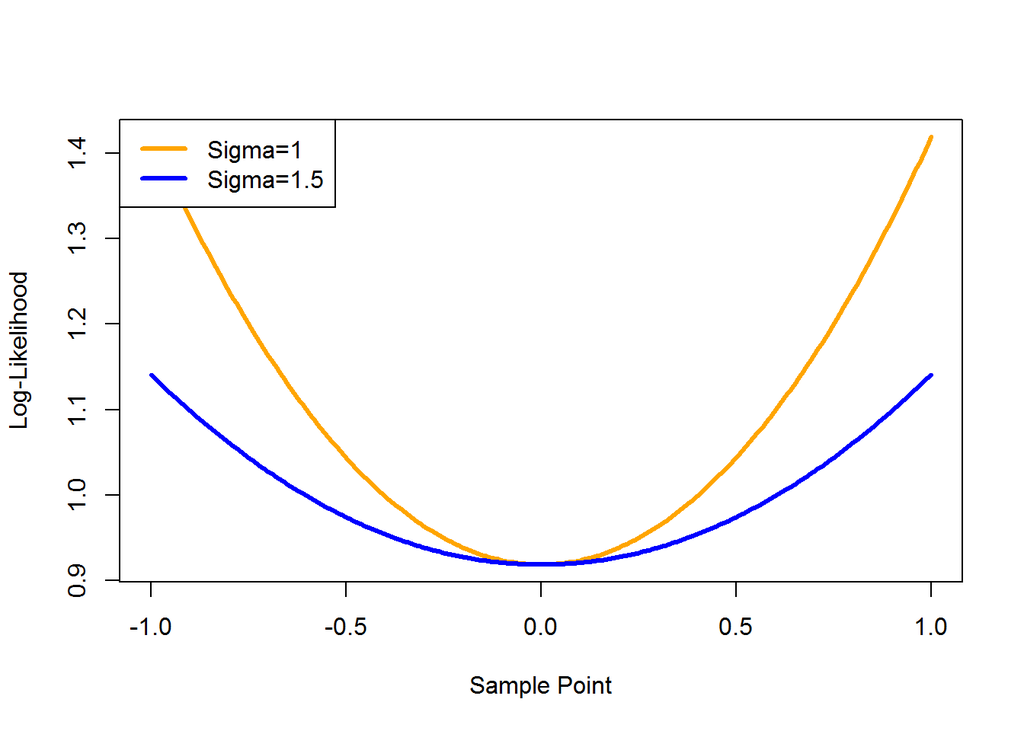

```r
Points.For.Plot<-seq(from=-1, to=1,by=.01)
LLF.Sigma.1<-sapply(Points.For.Plot, function(z) Negative.LL.Normal(c(z,1),0))
LLF.Sigma.2<-sapply(Points.For.Plot, function(z) Negative.LL.Normal(c(z,1.5^2),0))+
  Negative.LL.Normal(c(0,1),0)-Negative.LL.Normal(c(0,1.5^2),0)
matplot(Points.For.Plot,cbind(LLF.Sigma.1,LLF.Sigma.2),type="l",lty=1, lwd=3,col=c("orange","blue"),ylab="Log-Likelihood",xlab="Sample Point")
legend(x="topleft",legend=c("Sigma=1","Sigma=1.5"),lty=1,col=c("orange","blue"),lwd=3)
```

**Which case gives higher information about the unknown parameter $\mu$ in the one-observation sample $y_1=0$?**

It is obvious from the plot that in this example the MLE estimate $\mu_L=0$.

## 3.2 Fisher’s Information

Calculate Fisher’s information for both cases $I(\mu_L)=\frac{1}{\sigma^2}$

```r
Fisher.I.1<-1/1^2
Fisher.I.1.5<-1/1.5^2
```

## 3.3 Confidence intervals for $\mu_L$

Variance of $\mu_L$, given the sample $y_1=0$ is $V[\mu_L]=\frac{1}{I(\mu_L)}=\frac{\sigma^2}{n}$

```r
(STD.Mu.MLE.1<-sqrt(1/Fisher.I.1))
```

```
## [1] 1
```

```r
(STD.Mu.MLE.1.5<-sqrt(1/Fisher.I.1.5))
```

```
## [1] 1.5
```

A 95% confidence interval for $\mu_L$ is $[\mu_L-q_{0.975} \sigma_L,\mu_L+q_{0.975} \sigma_L]$ where $q_{0.975}$ is the 0.975-quantile of the standard normal distribution and $\sigma_L$ is the standard deviation of $\mu_L$.

For $\sigma=1$ the confidence interval is

```r
c(-qnorm(.975)*sqrt(STD.Mu.MLE.1),qnorm(.975)*sqrt(STD.Mu.MLE.1))
```

```
## [1] -1.959964  1.959964
```

For $\sigma=1.5$ the confidence interval is

```r
c(-qnorm(.975)*sqrt(STD.Mu.MLE.1.5),qnorm(.975)*sqrt(STD.Mu.MLE.1.5))
```

```
## [1] -2.400456  2.400456
```

# 4 Example: Simple linear regression

## 4.1 Data

Create data for simple linear regression.

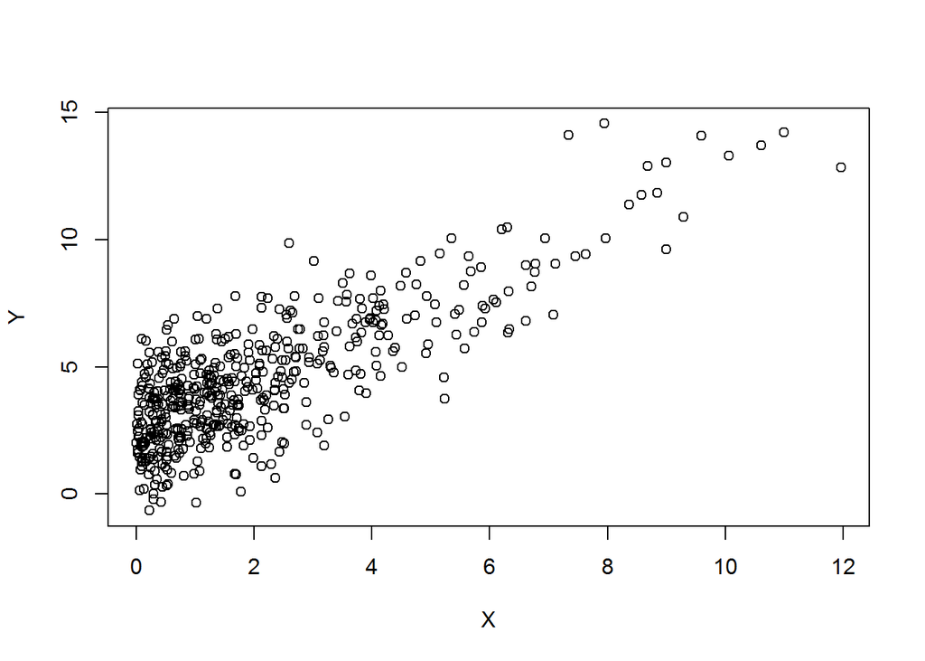

```r
nSample<-500
sigmaEps<-1.5
set.seed(927436)
Eps<-rnorm(nSample,0,sigmaEps)
beta1<-1
beta0<-2.5
lambda<-.5
X<-rexp(nSample,lambda)
Y<-beta0+beta1*X+Eps
plot(X,Y)
```

```r
dtf<-data.frame(X=X,Y=Y)
head(dtf)
```

```
##          X         Y
## 1 1.980506 4.0826325
## 2 2.542126 5.2707668
## 3 1.040133 6.9997564
## 4 1.694994 0.7666407
## 5 0.102001 1.9767673
## 6 2.751328 6.4738524
```

## 4.2 Loglikelihood function

Create negative log likelihood function for Gaussian distribution with arguments: parameters vector $\beta_0,~\beta_1,~\sigma$, data frame with column of predictor and column of response `linModLL<-function(Parameters,regSample)`.

**Hint**: use funcrion `dnorm()`.

(Skipped Code)

Check the function by substituting actual parameters values and some arbitrary parameters values.

```r
linModLL(c(Beta0=beta0+1,Beta1=beta1+1,Sigma=sigmaEps),dtf)
```

```
## [1] 2523.769
```

```r
linModLL(c(Beta0=beta0,Beta1=beta1,Sigma=sigmaEps),dtf)
```

```
## [1] 931.3951
```

## 4.3 Fit

Run `optim()` to find maximum likelihood estimates for intercept, slope and standard deviation.

(Skipped Code)

Look at the results.

```r
manualMLE$par
```

```
##     Beta0     Beta1     Sigma
## 2.4929481 0.9761938 1.5546999
```

```r
manualMLE$value
```

```
## [1] 930.1112
```

```r
manualMLE$counts
```

```
## function gradient
##       13       13
```

```r
manualMLE$hessian
```

```
##              Beta0        Beta1        Sigma
## Beta0 2.068602e+02 4.271255e+02 5.373096e-03
## Beta1 4.271255e+02 1.789051e+03 1.560386e-02
## Sigma 5.373096e-03 1.560386e-02 4.137235e+02
```

Compare the results with linear model fit.

```r
linM<-lm(Y~X,dtf)
res<-rbind(LM=c(linM$coefficients,summary(linM)$sigma),
           Manual=manualMLE$par,
           Actual=c(beta0,beta1,sigmaEps) )
colnames(res)<-c("Intercept","Slope","Sigma")
res
```

```
##        Intercept     Slope    Sigma
## LM      2.492960 0.9761977 1.557821
## Manual  2.492948 0.9761938 1.554700
## Actual  2.500000 1.0000000 1.500000
```